# 第八章 拉普拉斯变换

## 例2. 因果二阶系统

$$\frac {d ^ {2} y (t)}{d t ^ {2}} + 2 \zeta \omega_ {n} \frac {d y (t)}{d t} + \omega_ {n} ^ {2} y (t) = \omega_ {n} ^ {2} x (t)$$

$$H (s) = \frac {\omega_ {n} ^ {2}}{s ^ {2} + 2 \zeta \omega_ {n} s + \omega_ {n} ^ {2}} = \frac {\omega_ {n} ^ {2}}{(s - c _ {1}) (s - c _ {2})}, c _ {1, 2} = - \zeta \omega_ {n} \pm \omega_ {n} \sqrt {\zeta^ {2} - 1}$$

$$h (t) = M \left(e ^ {c _ {1} t} - e ^ {c _ {2} t}\right) u (t), \quad M = \frac {\omega_ {n}}{2 \sqrt {\zeta^ {2} - 1}}$$

1. 当 $\zeta > 1$， 有两个实数极点，$\left| H (j \omega) \right|$随着$|\omega|$的增加而单调下降，而$\arg H(j\omega)$则由$\omega = 0$时由$0$变为$\omega$趋向于$\infty$的$-\pi$

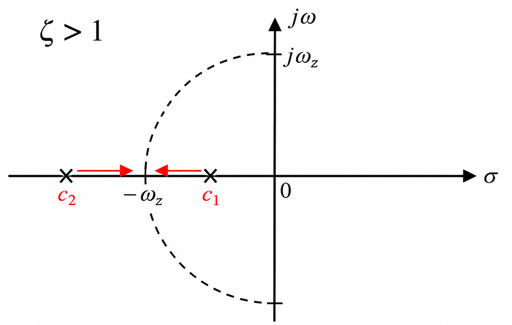

2. 当$0<\zeta<1$时，则二阶极点分裂为共轭复数极点，且随$\zeta$的减小而逐步靠近$j\omega$轴。极点运动的轨迹-根轨迹是一个半径为$\omega_n$的圆周

由于第2象限的极点矢量变得很短， 因而会使$|H(j\omega)|$出现峰值。其峰点位于$\omega_ {n} \sqrt {1 - \zeta^ {2}}$

随着$\omega$，位于第2象限的极点矢量比第3象限的极点矢量更短，因此它对系统特性的影响较大。

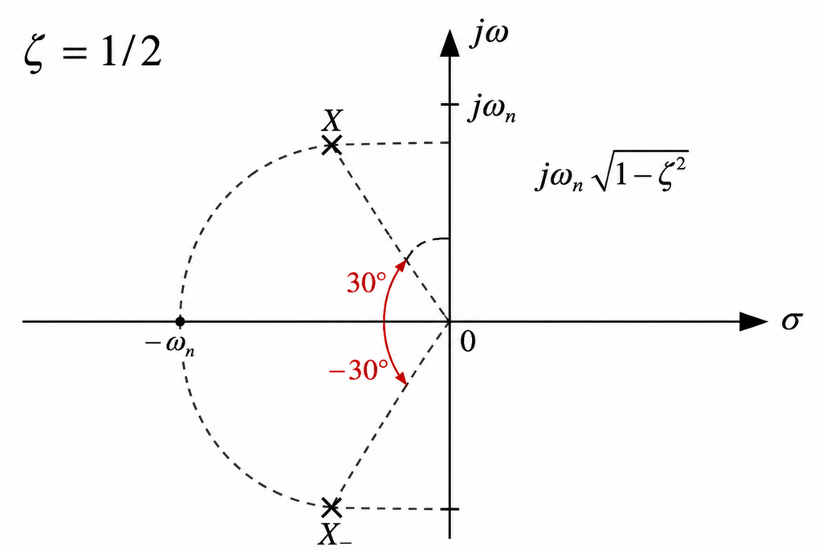

## 例3. 全通系统

考察零极点对称分布的系统
$$H (s) = \frac {s - a}{s + a} \quad \text{一阶全通}$$

该系统的$H(j\omega)$在任何时候都等于1，所以称为全通系统。

其相位特性

$$\arg H (j \omega) = \theta_ {1} - (\pi - \theta_ {1}) = 2 \theta_ {1} - \pi$$

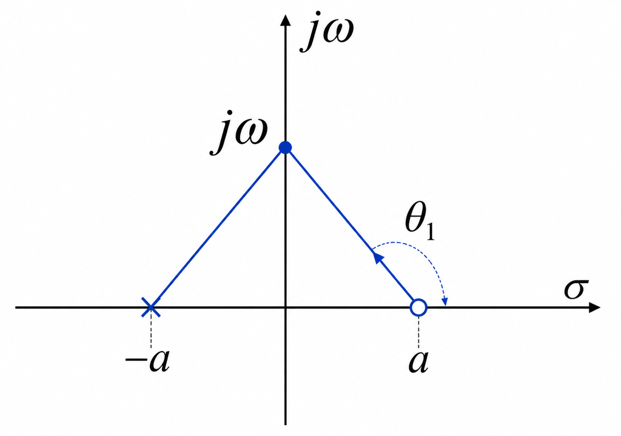

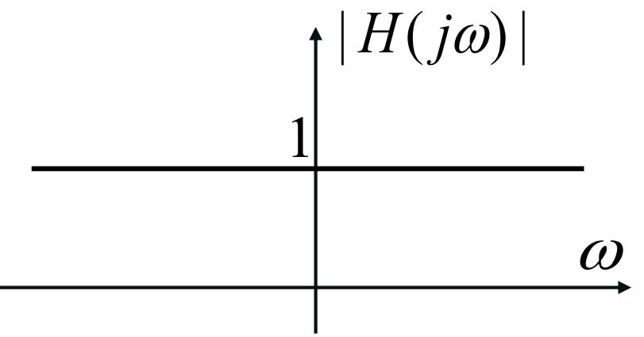

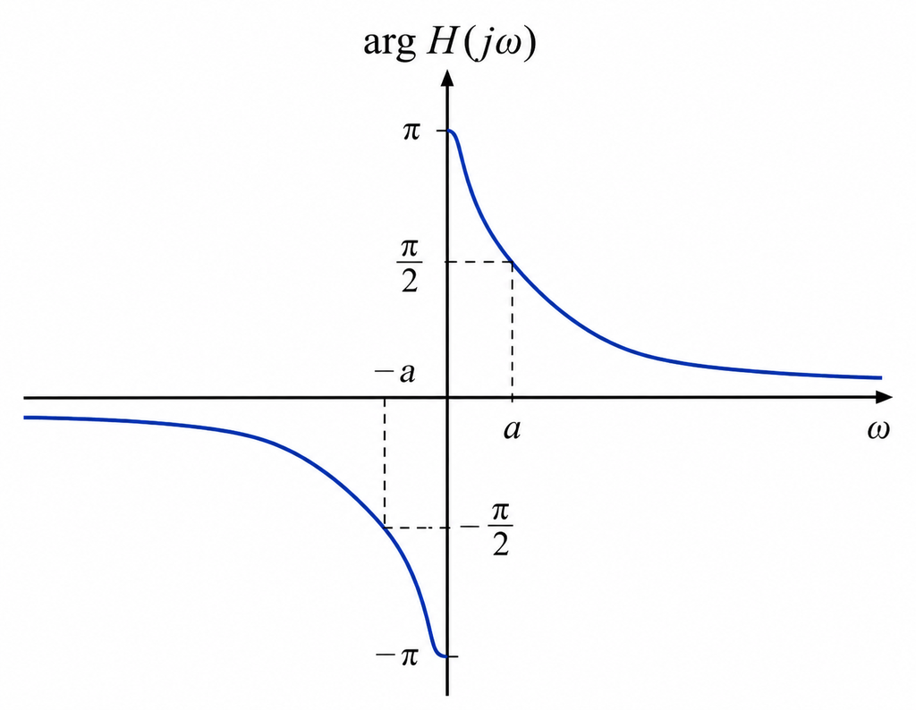

## 例4. 最小相位系统

考察两个系统，它们的极点相同，零点分布关于$j\omega$轴对称。其中一个系统的零点均在左半平面，另一个系统的零点均在右半平面。

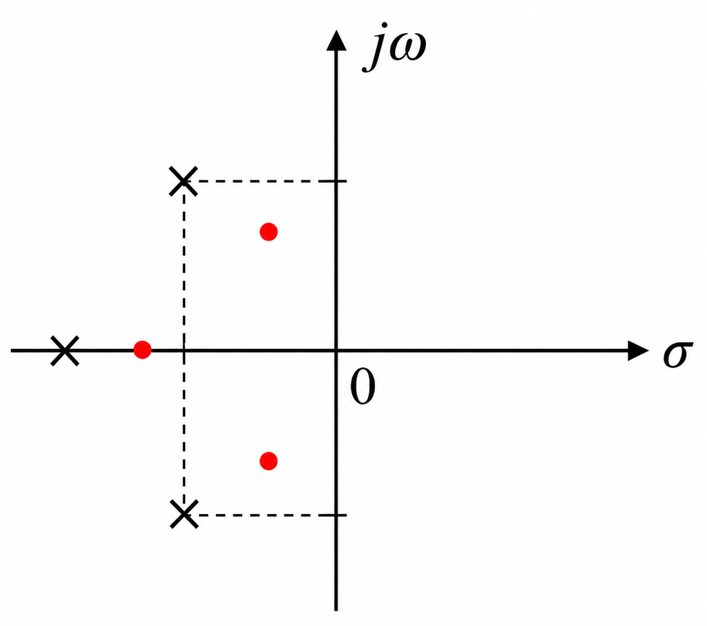

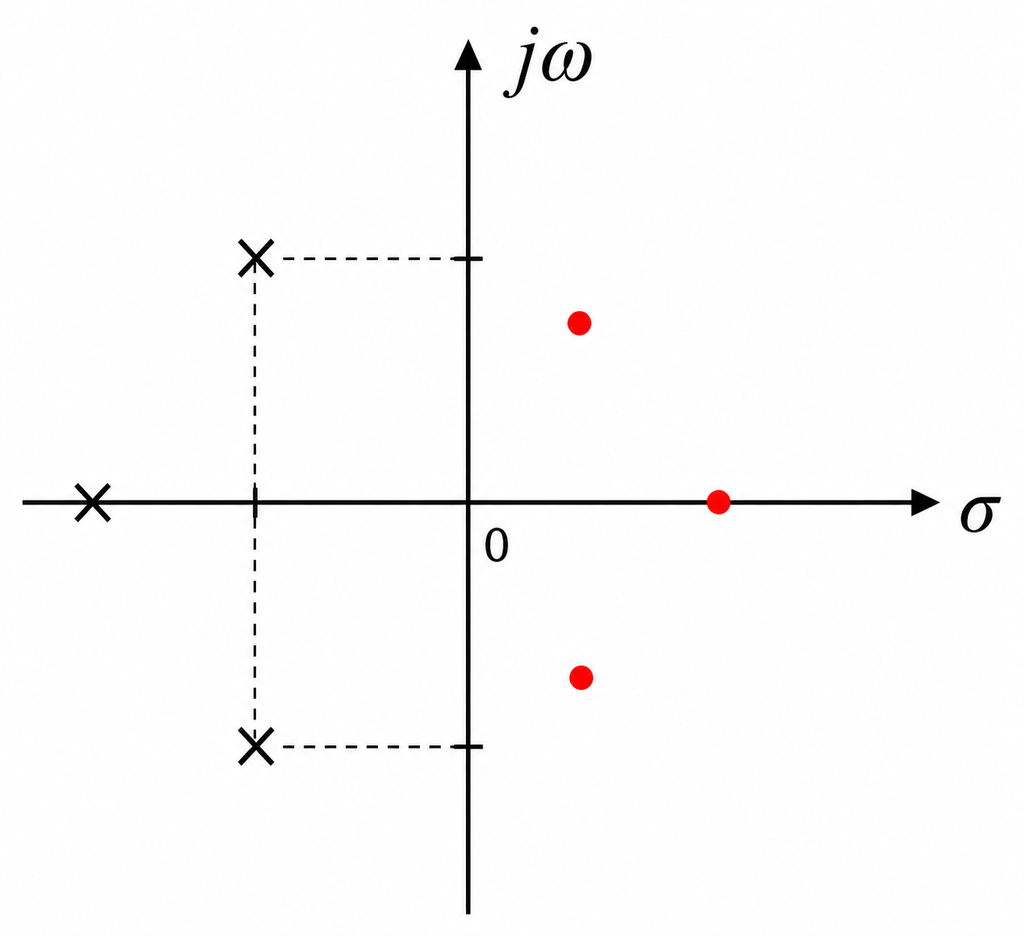

显然这两个系统的幅频特性是相同的。但零点在左半平面的系统其相位总小于零点在右半平面的系统。 因此将零极点均位于左半平面的系统称为最小相位系统。

## 例4. 最小相位系统

工程应用中设计的各种频率选择性滤波器，如：Butterworth 、Chebyshev、 Cauer滤波器都是最小相位系统。

从本质上讲系统的特性是由系统的零、极点分布决定的。对系统进行优化设计，实质上就是优化其零、极点的位置。

当工程应用中要求实现一个非最小相位系统时，通常采用将一个最小相位系统和一个全通系统级联来实现。

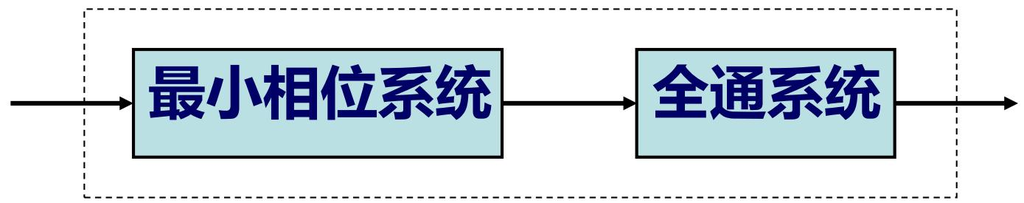

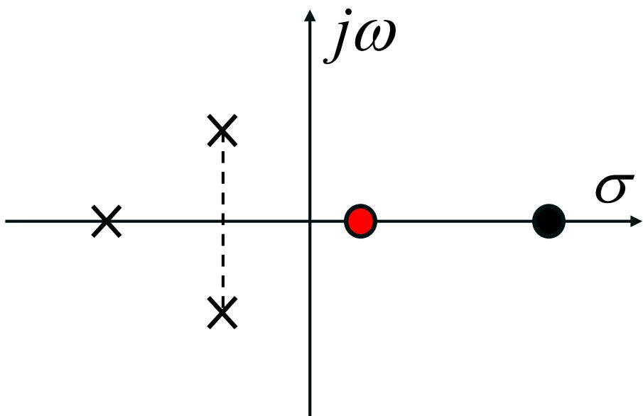

非最小相位系统

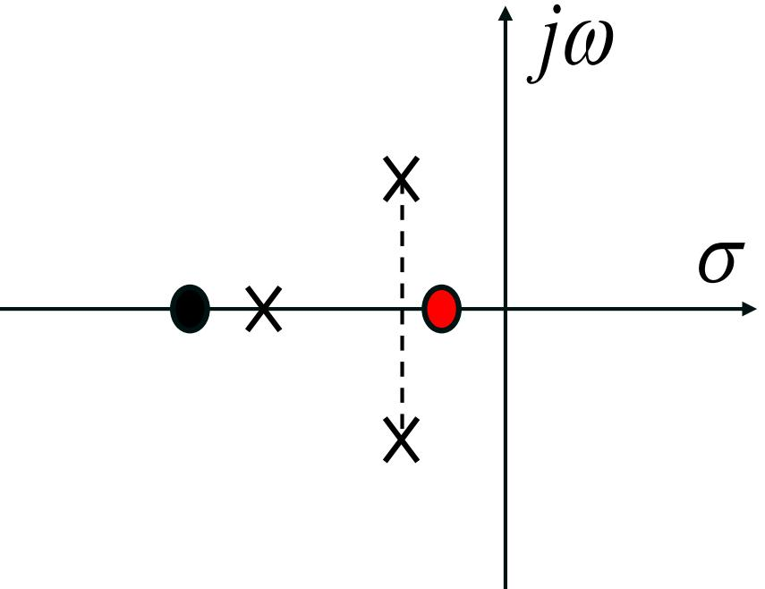

最小相位系统

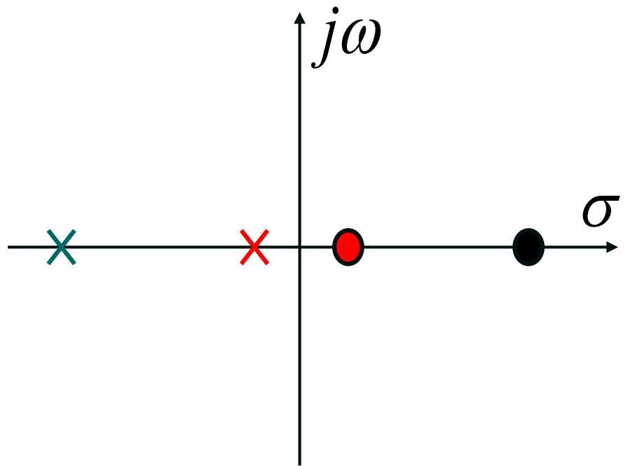

全通系统

## 目录

- 1. 引言
- 2. 拉普拉斯变换及其收敛域
- 3. 拉普拉斯逆变换
- 4. 拉普拉斯变换的性质
- 5. 常用拉普拉斯变换对
- 6. 由零极点图对傅里叶变换几何求值
- **7. 用拉普拉斯变换分析和表征线性时不变系统**
- 8. 单边拉普拉斯变换

# 用拉普拉斯变换分析和表征线性时不变系统

## 连续时间系统函数

回忆连续时间 LTI 系统对输入 $x(t)$ 的响应为

$$y(t) = (x * h)(t)$$

其中 $h$ 是冲激响应。

若 $x$ 和 $h$ 存在拉普拉斯变换，由卷积性质得

$$Y(s) = X(s) H(s)$$

在其公共 ROC 内（实际为 ROAC）。

若 ROC 有非空内点，系统函数（也称传递函数）$H(s)$ 通过拉普拉斯逆变换唯一确定 $h(t)$，进而确定系统性质。

## 因果性

回忆 $h$ 是右边信号当且仅当 $H(s)$ 的 ROC 是右半平面。

**因果 $\Longrightarrow$ ROC 是右半平面**

**注意**：逆命题不成立。

**例** 考虑 $H(s)=\frac{e^{s}}{s+1}$，ROC $\operatorname{Re} s > -1$。由时移性质，

$$h(t) = e^{-(t+1)} u(t+1)$$

该系统不是因果的。

## 因果性

**对于有理系统函数 $H(s)$ 的 LTI 系统，因果的充要条件是：ROC 是最右侧极点右侧的右半平面。**

**证明** 对有理系统函数，

$$H(s) = \sum_{k=1}^{n} a_{k} s^{k} + \sum_{i=1}^{r} \sum_{k_{i}=1}^{N_{i}} \frac{A_{i,k_{i}}}{(s+a_{i})^{k_{i}}}, \quad \operatorname{Re} s > \max_{i} \operatorname{Re}(-a_{i})$$

于是

$$h(t) = \sum_{k=1}^{n} a_{k} \delta^{(k)}(t) + \sum_{i=1}^{r} \sum_{k_{i}=1}^{N_{i}} \frac{A_{i,k_{i}}}{(k_{i}-1)!} t^{k_{i}-1} e^{-a_{i} t} u(t)$$

这是因果的。（也可由围线积分证明）

**例如** $h(t)=e^{-t} u(t) \stackrel{\mathcal{L}}{\longleftrightarrow} \frac{1}{s+1}$，ROC $\operatorname{Re} s > -1$，因果。

**例如** $h(t)=e^{-|t|} \stackrel{\mathcal{L}}{\longleftrightarrow} \frac{-2}{s^{2}-1}$，ROC $-1 < \operatorname{Re} s < 1$，非因果。

## 稳定性

LTI 系统稳定当且仅当其冲激响应 $h \in L_{1}$，即

$$\int_{-\infty}^{\infty} |h(t)| \, dt < \infty$$

这等价于 $H(s)$ 在虚轴 $\operatorname{Re} s=0$ 上绝对收敛，因此其 ROC 必须满足 $\sigma_{1} < 0 < \sigma_{2}$。

**稳定 $\Longleftrightarrow$ ROC 包含虚轴**

对于有理系统函数的**因果** LTI 系统，稳定的充要条件是所有极点的实部均为负。

**例如** 因果系统 $H(s)=\frac{1}{s+a}$ 在 $\operatorname{Re} a > 0$ 时稳定。

**例如** 若 $\operatorname{Re} a < 0$ 且 ROC 为 $\operatorname{Re} s < -\operatorname{Re} a$，系统也稳定，但非因果。

## 例

考虑系统函数

$$H(s) = \frac{1}{s-2} - \frac{1}{s+1}$$

有两个极点 $p_{1}=-1$ 和 $p_{2}=2$。

1. $\operatorname{Re} s < -1$：非因果，不稳定

$$h_{1}(t) = -e^{2t} u(-t) + e^{-t} u(-t)$$

2. $-1 < \operatorname{Re} s < 2$：非因果，稳定

$$h_{2}(t) = -e^{2t} u(-t) - e^{-t} u(t)$$

3. $\operatorname{Re} s > 2$：因果，不稳定

$$h_{3}(t) = e^{2t} u(t) - e^{-t} u(t)$$

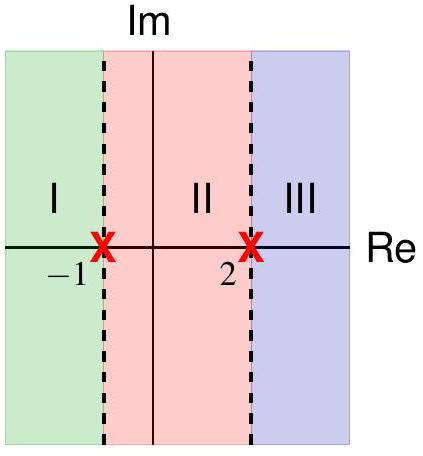

## 线性常系数微分方程

输入输出满足

$$\sum_{k=0}^{N} a_{k} \frac{d^{k} y}{dt^{k}} = \sum_{k=0}^{M} b_{k} \frac{d^{k} x}{dt^{k}}$$

两边取拉普拉斯变换：

$$\sum_{k=0}^{N} a_{k} s^{k} Y(s) = \sum_{k=0}^{M} b_{k} s^{k} X(s)$$

故系统函数

$$H(s) = \frac{Y(s)}{X(s)} = \frac{\sum_{k=0}^{M} b_{k} s^{k}}{\sum_{k=0}^{N} a_{k} s^{k}}$$

系统函数总是有理的。微分方程本身不指定 ROC！需要附加条件（如稳定性、因果性）来确定 $h(t)$。

## 例

考虑 LTI 系统满足

$$y'(t) + 3 y(t) = x'(t) + x(t)$$

系统函数

$$H(s) = \frac{s+1}{s+3} = 1 - \frac{2}{s+3}$$

ROC 有两种可能：$\operatorname{Re} s > -3$ 和 $\operatorname{Re} s < -3$

1. 若 $\operatorname{Re} s > -3$（因果且稳定）：

$$h(t) = \delta(t) - 2 e^{-3t} u(t)$$

2. 若 $\operatorname{Re} s < -3$（非因果且不稳定）：

$$h(t) = \delta(t) + 2 e^{-3t} u(-t)$$

## 例（续）

若使用傅里叶变换，频率响应为

$$H(j\omega) = \frac{j\omega + 1}{j\omega + 3} = 1 - \frac{2}{j\omega + 3}$$

对应

$$h(t) = \delta(t) - 2 e^{-3t} u(t)$$

为什么只有一种可能？

- 傅里叶变换方法隐含假设系统稳定，要求 $H(s)$ 的 ROC 包含虚轴，因此 $\operatorname{Re} s > -3$；
- 一般情况下不适用于不稳定系统。

## 例（续）

对输入 $x(t)=e^{-4t} u(t)$ 求响应。

$$X(s) = \frac{1}{s+4}, \quad \operatorname{Re} s > -4$$

响应变换

$$Y(s) = H(s) X(s) = \frac{s+1}{s+3} \cdot \frac{1}{s+4} = \frac{-2}{s+3} + \frac{3}{s+4}$$

**两种可能 ROC**：

1. $\operatorname{Re} s > -3$：

$$y(t) = -2 e^{-3t} u(t) + 3 e^{-4t} u(t)$$

2. $-4 < \operatorname{Re} s < -3$：

$$y(t) = 2 e^{-3t} u(-t) + 3 e^{-4t} u(t)$$

## 例（续）

对输入 $x(t)=e^{-3t} u(t)$ 求响应。

$$X(s) = \frac{1}{s+3}, \quad \operatorname{Re} s > -3$$

$$Y(s) = \frac{s+1}{s+3} \cdot \frac{1}{s+3} = \frac{1}{s+3} - \frac{2}{(s+3)^{2}}$$

只有一种可能的 ROC $\operatorname{Re} s > -3$：

$$y(t) = (1-2t) e^{-3t} u(t)$$

对非因果不稳定系统，$x*h$ 不可定义。

## 例

某 LTI 系统对输入 $x(t)=e^{-3t} u(t)$ 的响应为

$$y(t) = (e^{-t} - e^{-2t}) u(t)$$

系统函数

$$H(s) = \frac{Y(s)}{X(s)} = \frac{\frac{1}{s+1} - \frac{1}{s+2}}{\frac{1}{s+3}} = \frac{s+3}{s^{2} + 3s + 2}, \quad \operatorname{Re} s > -1$$

部分分式展开得

$$H(s) = \frac{2}{s+1} - \frac{1}{s+2}, \quad \operatorname{Re} s > -1 \Longrightarrow h(t) = (2e^{-t} - e^{-2t}) u(t)$$

该系统可由以下微分方程描述：

$$\frac{d^{2} y}{dt^{2}} + 3 \frac{dy}{dt} + 2 y = \frac{dx}{dt} + 3 x$$

## 系统互连

**串联（级联）系统**

$$Y = (X H_{1}) H_{2} = X (H_{1} H_{2}) = (X H_{2}) H_{1}$$

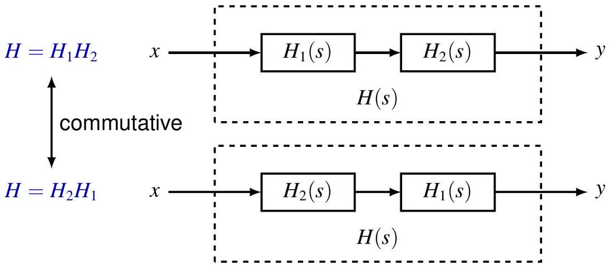

## 系统互连

**并联系统**

$$h = h_{1} + h_{2}$$

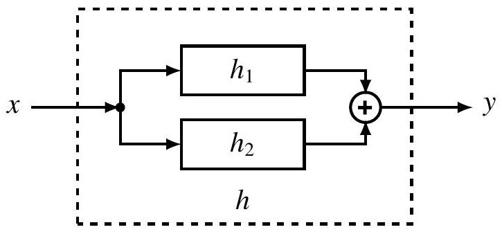

$$H = H_{1} + H_{2}$$

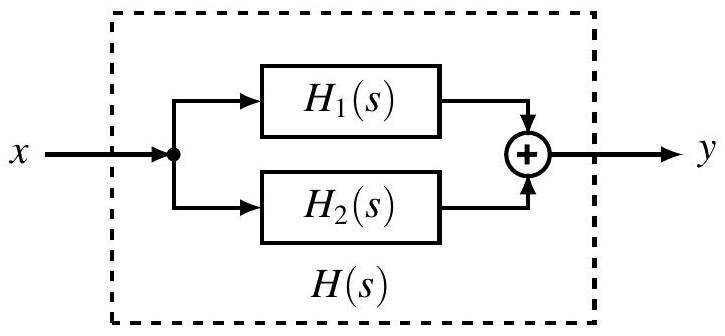

## 系统互连

**反馈系统**

$$y = h_{1} * (x - h_{2} * y)$$

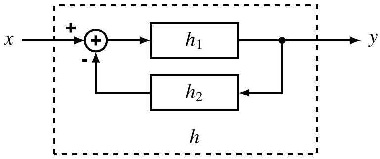

$$Y = H_{1} X - H_{1} H_{2} Y \Longrightarrow H = \frac{H_{1}}{1 + H_{1} H_{2}}$$

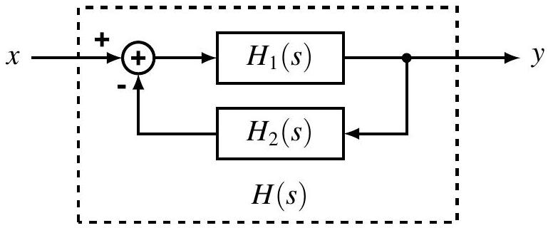

## 例

因果 LTI 系统，系统函数

$$H(s) = \frac{1}{s+a}, \quad \operatorname{Re} s > -\operatorname{Re} a$$

等价的微分方程描述：

$$y'(t) + a y(t) = x(t)$$

（初始松弛条件）

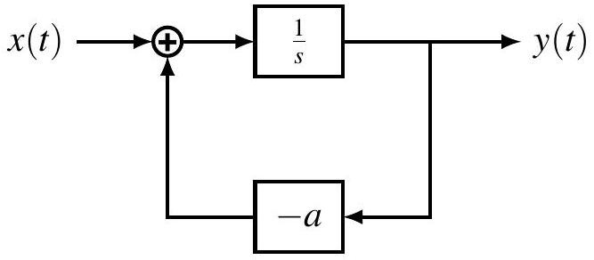

## 例

因果 LTI 系统，系统函数

$$H(s) = \frac{s+b}{s+a} = \left( \frac{1}{s+a} \right) (s+b), \quad \operatorname{Re} s > -\operatorname{Re} a$$

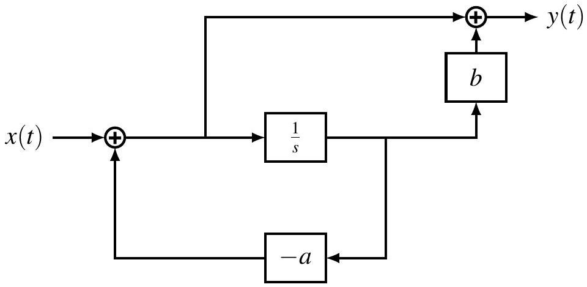

## 例

因果 LTI 系统，系统函数

$$H(s) = \frac{1}{(s+1)(s+2)} = \frac{1}{s^{2} + 3s + 2}$$

等价微分方程：

$$y''(t) + 3 y'(t) + 2 y(t) = x(t)$$

**直接形式**

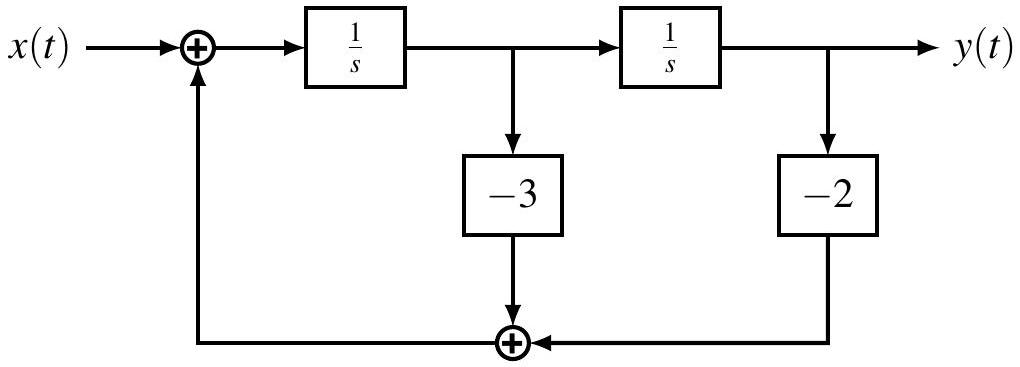

## 例

因果 LTI 系统，系统函数

$$H(s) = \frac{1}{(s+1)(s+2)} = \frac{1}{s+1}\frac{1}{ s+2}$$

**级联形式**

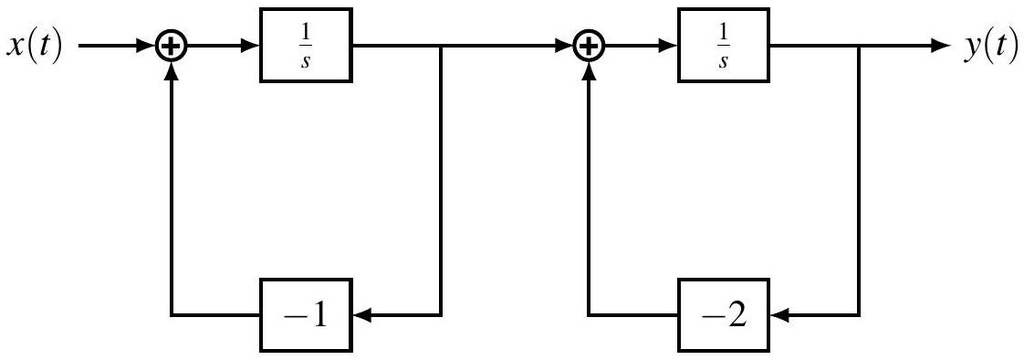

## 例

因果 LTI 系统，系统函数

$$H(s) = \frac{1}{(s+1)(s+2)} = = \frac{1}{s+1}-\frac{1}{ s+2}$$

**并联形式**

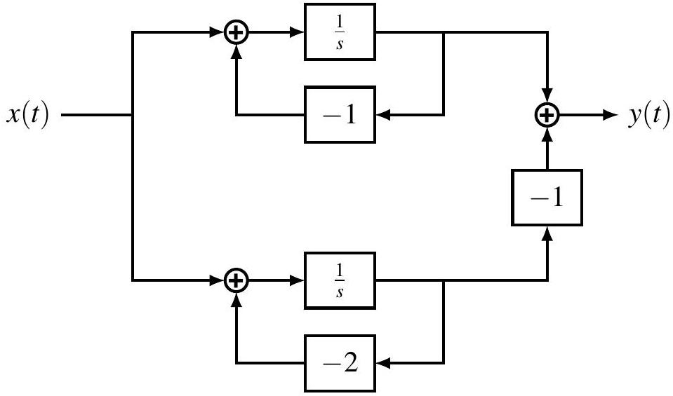

## 目录

- 1. 引言
- 2. 拉普拉斯变换及其收敛域
- 3. 拉普拉斯逆变换
- 4. 拉普拉斯变换的性质
- 5. 常用拉普拉斯变换对
- 6. 由零极点图对傅里叶变换几何求值
- 7. 用拉普拉斯变换分析和表征线性时不变系统
- **8. 单边拉普拉斯变换**

# 单边拉普拉斯变换

## 单边拉普拉斯变换

回忆连续时间信号 $x(t)$ 的（双边）拉普拉斯变换

$$X(s)=\int_{-\infty}^{\infty} x(t) e^{-s t} \, dt$$

$x(t)$ 的**单边拉普拉斯变换**为

$$\mathcal{X}(s)=\int_{0_{-}}^{\infty} x(t) e^{-s t} \, dt$$

也记作

$$\mathcal{X}=\mathcal{U}\mathcal{L}\{x\}, \quad x(t) \stackrel{\mathcal{UL}}{\longleftrightarrow} \mathcal{X}(s)$$

$\mathcal{X}(s)$ 的收敛域始终是右半平面。

**注**：$t<0$ 时 $x(t)$ 的信息在单边变换中丢失。

**注**：$\mathcal{L}\{x\}=\mathcal{U}\mathcal{L}\{x\}$ 当且仅当 $x(t)$ 是因果的，即 $x(t)=0$ 对 $t<0$ 成立。

## 例子

单边拉普拉斯变换的计算与双边拉普拉斯变换几乎相同。

**例** $x_{1}(t)=e^{-a t} u(t)$，

$$X_{1}(s)=\frac{1}{s+a}, \quad \operatorname{Re} s>-\operatorname{Re} a$$

**例** $x_{2}(t)=e^{-a(t+1)} u(t+1)=x_{1}(t+1)$，

$$\begin{array}{cl}
\text{双边} & X_{2}(s)=e^{s} X_{1}(s)=\frac{e^{s}}{s+a}, \quad \operatorname{Re} s>-\operatorname{Re} a \\
\text{单边} & X_{2}(s)=\int_{0}^{\infty} e^{-a(t+1)} e^{-s t} \, dt=\frac{e^{-a}}{s+a}, \quad \operatorname{Re} s>-\operatorname{Re} a
\end{array}$$

**注**：单边 $X_{2}(s) \neq$ 双边 $X_{2}(s)$，因为 $x_{2}(t)$ 是非因果的。

**注**：单边变换不满足时移性质，即 $X_{2}(s) \neq e^{s} X_{1}(s)$。

## 例子

单边拉普拉斯变换的计算与双边几乎相同。

**例** $x_{3}(t)=e^{-a|t|}$，$\operatorname{Re} a>0$，

$$\begin{aligned}
\text{双边} & X_{3}(s)=\frac{-2a}{s^{2}-a^{2}}, \quad -\operatorname{Re} a < \operatorname{Re} s < \operatorname{Re} a \\
\text{单边} & X_{3}(s)=\frac{1}{s+a}, \quad \operatorname{Re} s>-\operatorname{Re} a
\end{aligned}$$

**注**：$X_{3}(s) \neq X_{1}(s)$，因为 $x_{3}(t) \neq x_{1}(t)$。

**注**：单边 $X_{3}(s) = X_{1}(s)$，因为 $x_{3}(t)$ 与 $x_{1}(t)$ 仅在 $t<0$ 处不同。

**例** $x(t)=\delta(t)+2\delta'(t)+e^{t} u(t)$，

$$X(s)=\mathcal{X}(s)=1+2s+\frac{1}{s-1}, \quad \operatorname{Re} s>1$$

**注**：积分下限为 $0_{-}$，因此 $\delta(t)$ 和 $\delta'(t)$ 对单边变换有贡献。

## 例子

单边拉普拉斯逆变换的计算与双边相同，但只能恢复 $t \geq 0$ 的信号！

**例** 已知单边拉普拉斯变换

$$X(s)=\frac{1}{(s+1)(s+2)}=\frac{1}{s+1}-\frac{1}{s+2}$$

唯一可能的 ROC 是 $\operatorname{Re} s>-1$，因此

$$x(t)=e^{-t}-e^{-2t}, \quad t \geq 0$$

$X(s)$ 对 $t<0$ 的 $x(t)$ 无任何信息。

**例** $\mathcal{X}(s)=\frac{s^{2}-3}{s+2}=-2+s+\frac{1}{s+2}$，ROC 必为 $\operatorname{Re} s>-2$，故

$$x(t)=-2\delta(t)+\delta'(t)+e^{-2t}, \quad t \geq 0$$

## 单边拉普拉斯变换的性质

许多性质与双边拉普拉斯变换相同

| 性质 | 信号 | 单边拉普拉斯变换 |
| --- | --- | --- |
| - | $x(t)$ | $X(s)$ |
| - | $y(t)$ | $Y(s)$ |
| 线性 | $a x(t)+b y(t)$ | $a X(s)+b Y(s)$ |
| $s$ 域平移 | $e^{s_{0} t} x(t)$ | $X(s-s_{0})$ |
| 时间尺度变换 | $x(a t), a>0$ | $\frac{1}{a} X\left(\frac{s}{a}\right)$ |
| 共轭 | $x^{*}(t)$ | $X^{*}(s^{*})$ |
| $s$ 域微分 | $-t x(t)$ | $\frac{d}{ds} X(s)$ |

## 单边拉普拉斯变换的卷积性质

若 $x(t)=y(t)=0$ 对 $t<0$ 成立，则

$$(x * y)(t) \stackrel{\mathcal{UL}}{\longleftrightarrow} X(s) Y(s), \quad \text{ROAC} \supset \operatorname{ROAC}_{x} \cap \operatorname{ROAC}_{y}$$

**证明** 因为 $(x*y)(t)=0$ 对 $t<0$ 成立，

$$\mathcal{U}\mathcal{L}\{x*y\}=\mathcal{L}\{x*y\}=\mathcal{L}\{x\}\mathcal{L}\{y\}=\mathcal{U}\mathcal{L}\{x\}\mathcal{U}\mathcal{L}\{y\}$$

**注意**：$x(t)=y(t)=0$ 对 $t<0$ 的假设非常重要！

**例** $x(t)=\delta(t)-\delta(t-1)$，$y(t)=\delta(t+1)$，

$$X(s)=1-e^{-s}, \quad Y(s)=0$$

但 $(x*y)(t)=\delta(t+1)-\delta(t)$，

$$\mathcal{U}\mathcal{L}\{x*y\}=-1 \neq X(s)Y(s)$$

## 时域积分性质

若

$$x(t) \stackrel{\mathcal{UL}}{\longleftrightarrow} X(s), \quad \text{ROAC}=R$$

则

$$\int_{0_{-}}^{t} x(\tau) \, d\tau \stackrel{\mathcal{UL}}{\longleftrightarrow} \frac{1}{s} X(s), \quad \text{ROAC} \supset R \cap \{\operatorname{Re} s>0\}$$

**证明** 对 $\tilde{x} * u$ 应用卷积性质，其中

$$\tilde{x}(t) = \begin{cases}
x(t), & t \geq 0 \\
0, & t<0
\end{cases}$$

**例** $x(t)=\delta(t)$，$X(s)=1$，则

$$\int_{0_{-}}^{t} x(\tau) \, d\tau = u(t) \stackrel{\mathcal{UL}}{\longleftrightarrow} \frac{1}{s}, \quad \operatorname{Re} s>0$$

## 时域微分性质

若

$$x(t) \stackrel{\mathcal{UL}}{\longleftrightarrow} X(s), \quad \text{ROC}=R$$

且对 $s \in R_{0}$ 有 $\lim_{t\to+\infty} x(t) e^{-s t}=0$，则

$$\frac{d}{dt} x(t) \stackrel{\mathcal{UL}}{\longleftrightarrow} s X(s) - x(0_{-}), \quad \text{ROC} \supset R \cap R_{0}$$

**注**：$R_{0} \supset$ $X(s)$ 的 ROAC（双边拉普拉斯变换也成立）。

**证明** 分部积分：

$$\int_{0_{-}}^{\infty} x'(t) e^{-s t} \, dt = \left. x(t) e^{-s t} \right|_{0_{-}}^{\infty} + s \int_{0_{-}}^{\infty} x(t) e^{-s t} \, dt = -x(0_{-}) + s X(s)$$

**注**：若采用积分下限 $0_{+}$ 的定义，则有 $\frac{d}{dt}x(t) \stackrel{\mathcal{UL}}{\longleftrightarrow} s X(s) - x(0_{+})$。

## 时域微分性质

**例** $x(t)=e^{-t}$，$\mathcal{X}(s)=\frac{1}{s+1}$，ROAC $\operatorname{Re} s>-1$。由微分性质：

$$x'(t) \stackrel{\mathcal{UL}}{\longleftrightarrow} \frac{s}{s+1} - 1 = -\frac{1}{s+1}, \quad \operatorname{ROC} \supset \{\operatorname{Re} s>-1\}$$

直接计算验证一致。

**例** $x(t)=e^{-t} u(t)$，$X(s)=\frac{1}{s+1}$，ROAC $\operatorname{Re} s>-1$。由微分性质得

$$x'(t) \stackrel{\mathcal{UL}}{\longleftrightarrow} \frac{s}{s+1}$$

直接计算：$x'(t)=\delta(t)-e^{-t}u(t)$，

$$\mathcal{U}\mathcal{L}\{x'\}=\frac{s}{s+1}$$

## 时域微分性质

在适当条件下（如 $x^{(k)}(t)=O(e^{\gamma t})$），微分性质可推广到高阶导数：

$$x^{(n)}(t) \stackrel{\mathcal{UL}}{\longleftrightarrow} s^{n} X(s) - \sum_{k=0}^{n-1} s^{n-1-k} x^{(k)}(0_{-})$$

常系数微分方程的解形式为 $\sum p_{i}(t) e^{a_{i} t}$（$p_{i}$ 为多项式），满足上述条件。

单边拉普拉斯变换特别适用于求解具有非零初始条件的常系数微分方程。

## 初值定理

**定理** 若 $x(t)$ 的单边拉普拉斯变换 $\mathcal{X}(s)$ 是有理严格真函数，则

$$x(0_{+}) = \lim_{s \to \infty} s \mathcal{X}(s)$$

**证明** $\mathcal{X}(s)$ 的部分分式展开为

$$\mathcal{X}(s)=\sum_{i=1}^{r} \sum_{k_{i}=1}^{N_{i}} \frac{A_{i,k_{i}}}{(s+a_{i})^{k_{i}}}$$

$$x(t)=\sum_{i=1}^{r} \sum_{k_{i}=1}^{N_{i}} \frac{A_{i,k_{i}} t^{k_{i}-1}}{(k_{i}-1)!} e^{-a_{i} t}, \quad t \geq 0$$

于是

$$x(0_{+})=\sum_{i=1}^{r} A_{i,1} = \lim_{s\to\infty} s \mathcal{X}(s)$$

**例** $x(t)=2e^{-t}+e^{-2t}$，$\mathcal{X}(s)=\frac{3s+5}{s^{2}+3s+2}$，$x(0_{+})=\lim_{s\to\infty} s\mathcal{X}(s)=3$。

## 初值定理（非严格真情况）

若 $\mathcal{X}(s)$ 是有理但非严格真函数，

$$\mathcal{X}(s)=\sum_{k=0}^{n} a_{k} s^{k} + \mathcal{X}_{1}(s)$$

其中 $\mathcal{X}_{1}(s)$ 是严格真有理函数。逆变换为

$$x(t)=\sum_{k=0}^{n} a_{k} \delta^{(k)}(t) + x_{1}(t)$$

因此

$$x(0_{+})=x_{1}(0_{+})=\lim_{s\to\infty} s \mathcal{X}_{1}(s)$$

**例** $x(t)=\delta(t)+2e^{-t}$，$X(s)=1+\frac{2}{s+1}=\frac{s+3}{s+1}$，

$$x(0_{+})=2=\lim_{s\to\infty} \frac{2s}{s+1} \neq \lim_{s\to\infty} s X(s)$$

## 例

某连续时间 LTI 系统具有以下性质：

1. 系统是因果的；
2. 系统函数 $H(s)$ 是有理严格真函数，仅有两个极点 $s=-2$ 和 $s=-4$；
3. 输入 $x(t)=1$ 时，输出 $y(t)=0$；
4. 冲激响应满足 $h(0_{+})=4$。

求系统函数 $H(s)$。

**解** 由 1 和 2：

$$H(s)=\frac{a s + b}{(s+2)(s+4)}, \quad \operatorname{Re} s > -2$$

由 3：$H(0)=0$，故 $b=0$。

由 4：$\lim_{s\to\infty} s H(s)=4$，故 $a=4$，

$$H(s)=\frac{4s}{(s+2)(s+4)}, \quad \operatorname{Re} s > -2$$

## 终值定理

**定理** 假设 $x(t)$ 在 $t \geq 0$ 时不含 $\delta(t)$ 及其导数。若 $X(s)$ 对实数 $s>0$ 收敛，且 $\lim_{t\to+\infty} x(t)$ 存在有限，则

$$\lim_{t\to+\infty} x(t) = \lim_{s\to 0_{+}} s X(s)$$

**证明**

根据拉普拉斯变换的微分性质：
$$\mathcal{L}\{x'(t)\} = \int_{0^-}^{\infty} x'(t)e^{-st} dt = sX(s) - x(0^-)$$

由于 $x(t)$ 为因果信号且不含 $t=0$ 处的冲激，故 $x(0^-) = 0$。上式简化为：
$$sX(s) = \int_{0^-}^{\infty} x'(t)e^{-st} dt = \int_{0^-}^{\epsilon} x'(t)e^{-st} dt + \int_{\epsilon}^{\infty} x'(t)e^{-st} dt$$

## 终值定理（扩展）

终值定理可扩展至允许 $t>0$ 上有有限个 $\delta$ 及其导数的情况。此时

$$x(t)=x_{1}(t)+\sum a_{i} \delta^{(k_{i})}(t-t_{i}) \stackrel{\mathcal{UL}}{\longleftrightarrow} X(s)=X_{1}(s)+\sum a_{i} s^{k_{i}} e^{-s t_{i}}$$

$$\lim_{t\to+\infty} x(t)=\lim_{t\to+\infty} x_{1}(t)=\lim_{s\to 0_{+}} s X_{1}(s)=\lim_{s\to 0_{+}} s X(s)$$

**例** $x(t)=\delta(t)+2$，$\mathcal{X}(s)=\frac{2}{s}+1$，$x(+\infty)=2=\lim_{s\to 0_{+}} s \mathcal{X}(s)$。

## 线性常系数微分方程

考虑常系数微分方程

$$\sum_{k=0}^{N} a_{k} \frac{d^{k} y}{dt^{k}} = \sum_{k=0}^{M} b_{k} \frac{d^{k} x}{dt^{k}}$$

初始条件 $y^{(k)}(0_{-})$ 已知，输入因果（$x(t)=0$ 对 $t<0$）。

两边取单边拉普拉斯变换：

$$\sum_{k=0}^{N} a_{k} \left[ s^{k} Y(s) - \sum_{\ell=0}^{k-1} s^{k-1-\ell} y^{(\ell)}(0_{-}) \right] = \sum_{k=0}^{M} b_{k} s^{k} X(s)$$

整理得

$$Y(s) = \underbrace{\frac{\sum b_{k} s^{k}}{\sum a_{k} s^{k}} X(s)}_{\text{零状态响应}} + \underbrace{\frac{\sum_{k=0}^{N} a_{k} \sum_{\ell=0}^{k-1} s^{k-1-\ell} y^{(\ell)}(0_{-}) }{\sum a_{k} s^{k}} }_{\text{零输入响应}}$$

## 例

考虑微分方程

$$y''(t) + 3 y'(t) + 2 y(t) = 2 x'(t) + 6 x(t)$$

初始条件 $y(0_{-})=c_{0}$，$y'(0_{-})=c_{1}$，输入 $x(t)=e^{-t} u(t)$。

取单边拉普拉斯变换：

$$[s^{2} Y(s)-s c_{0}-c_{1}] + 3[s Y(s)-c_{0}] + 2 Y(s) = \frac{2s+6}{s+1}$$

解得

$$Y(s) = \frac{2s+6}{(s^{2}+3s+2)(s+1)} + \frac{c_{0} s + (3c_{0}+c_{1})}{s^{2}+3s+2}$$

$$= \underbrace{\frac{2s+6}{(s+1)^{2}(s+2)}}_{\text{零状态响应}} + \underbrace{\frac{c_{0} s + (3c_{0}+c_{1})}{(s+1)(s+2)}}_{\text{零输入响应}}$$

## 例（续）

**零状态响应**

$$Y_{zs}(s)=\frac{2s+6}{(s+1)^{2}(s+2)}, \quad \operatorname{Re} s > -1$$

对 $t \geq 0$，

$$y_{zs}(t) = 2 e^{-2t} + (4t-2) e^{-t}$$

**零输入响应**

$$y_{zi}(t) = (2c_{0}+c_{1}) e^{-t} - (c_{0}+c_{1}) e^{-2t}, \quad t \geq 0$$

## 作业

1. 9.1
2. 9.5
3. 9.8
4. 9.14
5. 9.20

# 第八章 拉普拉斯变换 完